# Improving the prediction of bus arrival using real-time network state

Tom Elliott

25 August 2020

# Part I

### What is the status quo, and what is wrong with it?

## In Auckland …

- real-time vehicle locations
- arrival and departure times/delays
- ETA = scheduled arrival + current delay
- *no use of location information, traffic, historical, …*

## Around the world …

- many unique real-time information systems
- various data feeds:
  - *vehicle positions, passenger counters, taxis, …*
- equally different prediction systems
  - *Kalman filter, artificial neural network, support vector machines, …*
- GTFS: *General Transit Feed Specification*

## Vehicle models

- operations management
  - *on-time performance, reducing bunching behaviour, …*
- little recent focus on ETAs
  - Kalman filter (e.g., Dailey et al. (2001), Cathey & Dailey (2003))
  - ANN/SVM (e.g., Yu et al. (2006), …)
- but lots of cool models
  - particle filtering (e.g., Hans et al. (2015))

## Traffic models

- essential for reliable predictions
- difficult to model (data availability, …)
- location-specific examples
  - Yu et al. (2011) *previous bus along same road, different route*
  - Julio et al. (2016) *traffic shockwaves*
  - … *taxi data*
- vast majority of transit feeds use *only* GTFS

## Arrival time prediction & journey planning

- current position, travel times, dwell times
- GTFS default: *schedule + current delay*
- usually a point estimate “*ETA: 5 mins*”
- JP is hard (Horn (2004), Häme & Hakula (2013))
- Simple to complex questions
  - which bus to arrive on time
  - which set of buses to get to destination fastest
  - minimal waiting time between legs
- Bérczi et al. (2017): use of probabilistic arrival time information

# Part II

### Bus arrival prediction using real-time network state

1. GTFS network construction
2. Vehicle model
3. Transit network model
4. Arrival time prediction
5. Journey planning

## 1. GTFS network construction

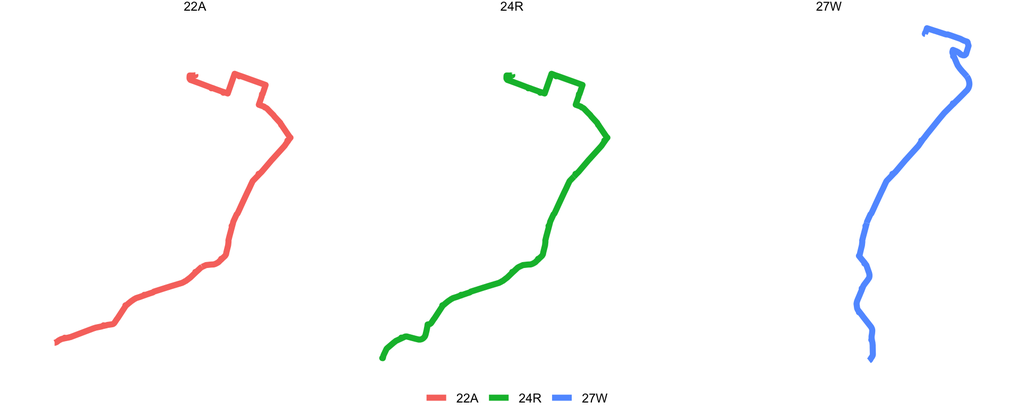

```r
library(transitr)
nw <- create_gtfs("https://cdn01.at.govt.nz/data/gtfs.zip",
    db = "at_gtfs.sqlite")
nw %>% construct()
```

## 1. GTFS network construction

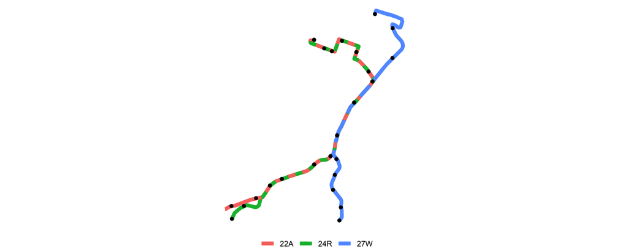

```r
library(transitr)
nw <- create_gtfs("https://cdn01.at.govt.nz/data/gtfs.zip",
    db = "at_gtfs.sqlite")
nw %>% construct()
```

## 1. GTFS network construction

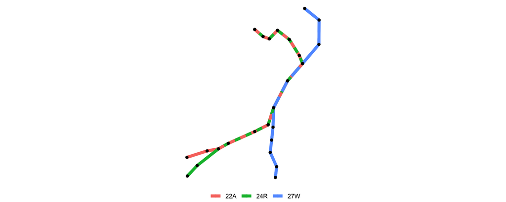

```r
library(transitr)
nw <- create_gtfs("https://cdn01.at.govt.nz/data/gtfs.zip",
    db = "at_gtfs.sqlite")
nw %>% construct()
```

## 2. Vehicle model

- Observations $\boldsymbol{y}_1, \boldsymbol{y}_2, \cdots, \boldsymbol{y}_{k-1}, \boldsymbol{y}_k$
- Underlying state $\boldsymbol{x}_0, \boldsymbol{x}_1, \cdots, \boldsymbol{x}_{k-2}, \boldsymbol{x}_k$
- Recursive Bayesian estimation: **Predict** and **Update**
- Estimates distance, speed, *average speed along each road segment*

## 3. Transit network model

- Observations $b_{v\ell c}$ with error $e_{v\ell c}$
  - average speed of vehicle $v$, road $\ell$, time period $(t_{c-1},t_c]$
- Underlying state $\beta_{\ell c}$ (average vehicle speed, m/s)
- Hierarchical structure
  $$\begin{split}
  b_{v\ell c} &\sim \mathcal{N}(B_{v\ell c}, e_{v\ell c}^2) \\
  B_{v\ell c} &\sim \mathcal{N}_T(\beta_{\ell c}, \phi_\ell^2) \\
  \beta_{\ell c} &\sim \mathcal{N}_T(F_c(\beta_{\ell,c-1}, \Delta_c), q^2),\quad
  \Delta_c = t_c - t_{c-1}
  \end{split}$$

## 3. Transit network model

- Historical data to estimate $\phi_\ell$ and $q$
- JAGS (Plummer, 2003)
- Kalman filter: real-time network state
  - $\hat \beta_{c|c-1} = \mathbb{E}(\beta_c | b_{0:c-1})$
  - $P_{c|c-1} = \mathrm{Var}(\beta_c | b_{0:c-1})$
- Information filter
  - Multiple vehicles/segment/time period
  - Limited to independent segments

## 3. Transit network model: results

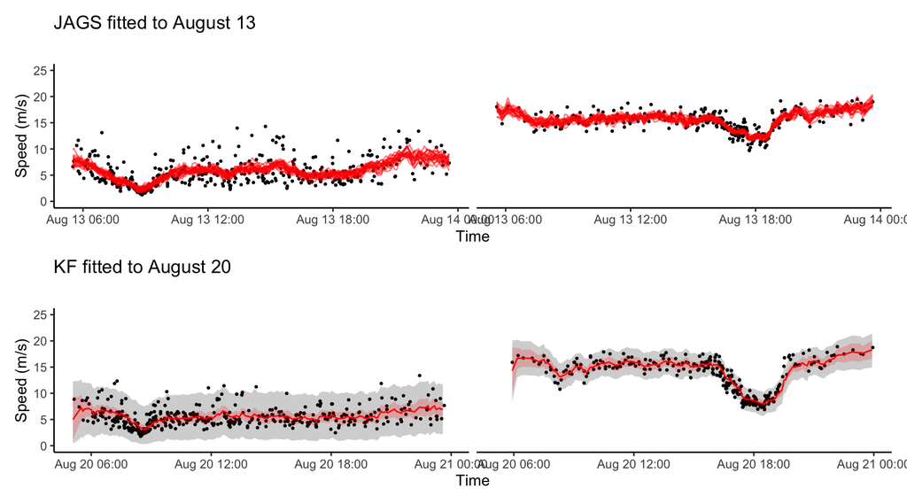

$\hat\beta_\ell$ $\pm 1.96\sqrt{\vphantom{x^2}P_\ell}$ and $\hat\beta_\ell$ $\pm 1.96\sqrt{P_\ell + \phi_\ell^2}$

## 4. Arrival time prediction

- ETA = travel time + dwell time
  - Shalaby & Farhan (2004), Jeong & Rilett (2005), Hans et al. (2015)
- Travel times: sum of (distributions) of segment travel times
  - travel time = distance / speed
- Dwell times: multimodality (dwell can be zero)

## 4. Arrival time prediction

- Particle filter
  - particles complete route recording arrival times
  - handles dwell time, layovers, etc.

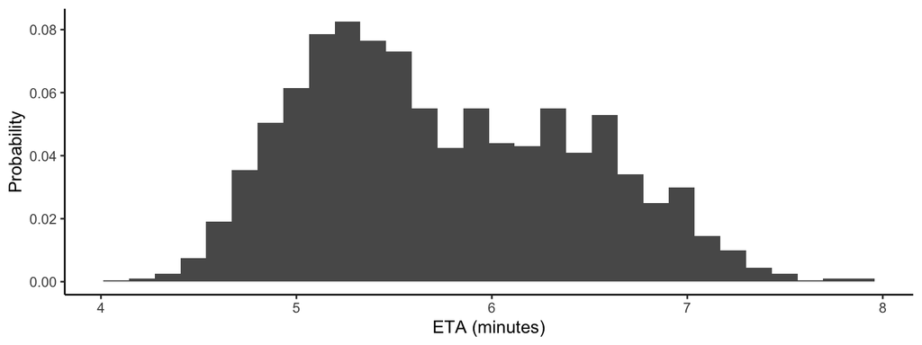

## 5. Journey planning

- Need a useful summary of $p(\alpha_j|\boldsymbol{x}_k, \boldsymbol{\beta}_k)$
- ETAs expected as integer minutes
- CDF approximation
  $$\mathbb{P}(A < a) = \sum_{x=0}^{x=a-1} \mathbb{P}(A \in [x, x+1))
  = \sum_{x=0}^{x=a-1} \left( \frac{1}{N^\star} \sum_{i=1}^{N^\star} I_{\lfloor \alpha^{(i)}/60 \rfloor = x} \right)$$

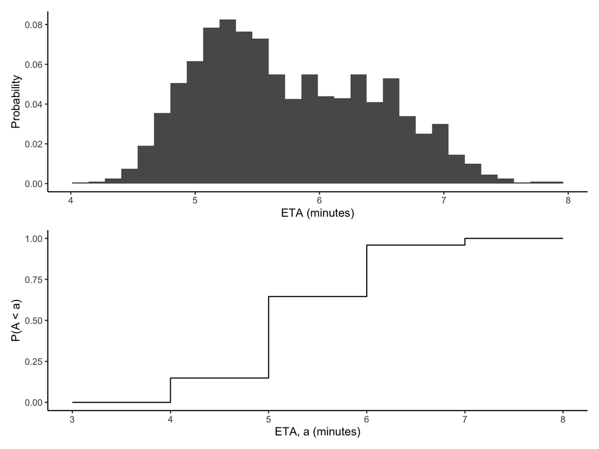

## 5. Journey planning

- CDF allows us to answer questions:
  - change of catching bus if I arrive at $a$
  - which bus should I catch to have at least 90% change of on-time arrival
  - probabilty of making transfer between two services
- Provides event probabilities (not binary ‘Yes’ or ‘No’)

# Part III

### Using particle filtering to model vehicles and generate arrival time distributions

## Why the particle filter?

- Flexible with few assumptions
- Handles complex vehicle behaviour
- Intuitive likelihood
- Multimodality

## Why not the particle filter?

- Computationally intensive
- Hard to distribute the results

## Why not the particle filter?

- Computationally intensive
- Hard to distribute the results

## Particle filter in action

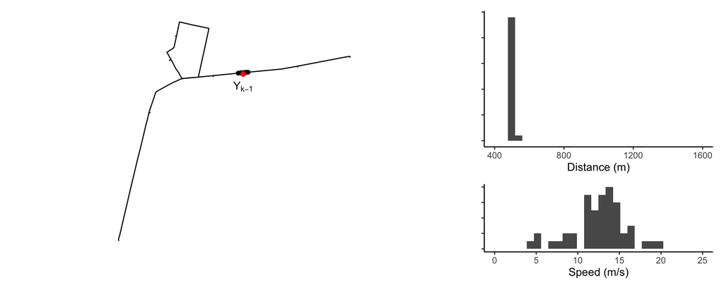

$$p(\boldsymbol{x}_{k-1} | \boldsymbol{y}_{1:k-1}) \approx
\sum_{i=1}^N w_{k-1}^{(i)} \delta_{\boldsymbol{x}_{k-1}^{(i)}} (\boldsymbol{x}_{k-1})$$

$N = 50$

## Particle filter in action: predict

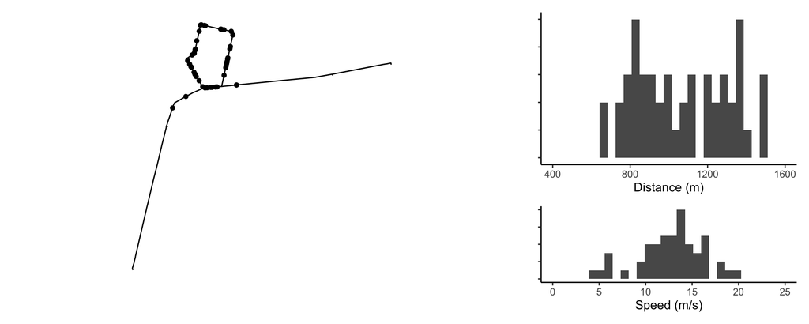

$$p(\boldsymbol{x}_{k} | \boldsymbol{x}_{k-1}) \approx
\sum_{i=1}^N w_{k-1}^{(i)} \delta_{\boldsymbol{x}_{k}^{(i)}} (\boldsymbol{x}_{k})$$

$\boldsymbol{x}_k^{(i)} = f(\boldsymbol{x}_{k-1}^{(i)}, \Delta_k, \sigma^2)$, $\Delta_k = t_k - t_{k-1} = 60$

## Particle filter in action: update

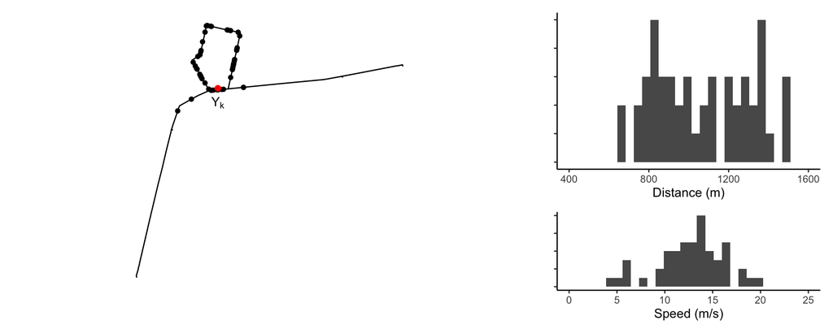

$$p(\boldsymbol{y}_{k} | \boldsymbol{x}_{k}) = ??$$

## Particle filter in action: likelihood

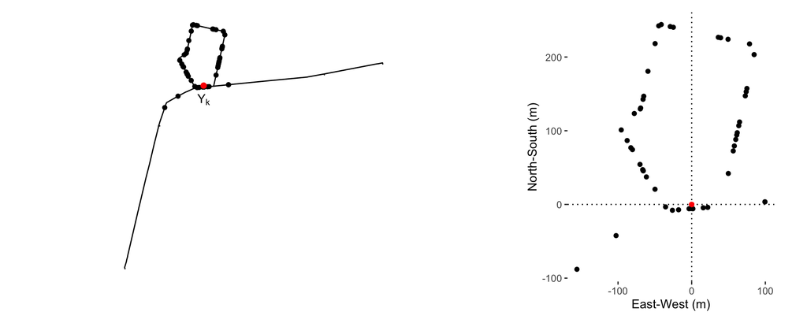

$$d(\boldsymbol{y}_k | h(\boldsymbol{x}_k^{(i)}) = ||g(\boldsymbol{y}_k | h(\boldsymbol{x}_k^{(i)}) ||
= ||\boldsymbol{r}_k^{(i)}||$$

Assumption: $\boldsymbol{r}_k \sim \mathcal{N}(\boldsymbol{0}, \epsilon^2\mathbf{I})$

Therefore: $d(\boldsymbol{y}_k | h(\boldsymbol{x}_k^{(i)})^2 \sim \mathcal{E}\left(\frac{1}{2\epsilon^2}\right)$

## Particle filter in action: update

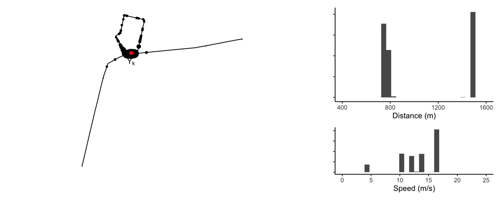

$$w_k^{(i)} = \frac{w_{k-1}^{(i)} p(\boldsymbol{y}_k | \boldsymbol{x}_k^{i})}{\sum_{j=1}^N w_{k-1}^{(j)} p(\boldsymbol{y}_k | \boldsymbol{x}_k^{j})}
,\quad
p(\boldsymbol{x}_{k} | \boldsymbol{y}_{1:k}) \approx
\sum_{i=1}^N w_{k}^{(i)} \delta_{\boldsymbol{x}_{k}^{(i)}} (\boldsymbol{x}_{k})$$

## Particle filter to estimate vehicle state

- Easy to model vehicle behaviour
  - acceleration/deceleration
  - bus stop dwell times
  - intersections
- Multimodality
  - bus stops
  - loops
  - bad data
- Easy estimation of other quantities …
  - travel time/average speed along road segments

$$p(b_\ell | \boldsymbol{y}_{1:k}) \approx
\sum_{i=1}^N w_{k}^{(i)} \delta_{b_{\ell}^{(i)}} (b_{\ell})$$

## Particle filter to predict arrival times

- Each particle travels to end of route
  - average segment speeds (distribution)
  - dwell times and layovers
  - intersections
- Arrival times $\alpha_j$ recorded

$$p(\alpha_j | \boldsymbol{\beta}_{k}, \boldsymbol{x}_{k}) \approx
\sum_{i=1}^N w_{k}^{(i)} \delta_{\alpha_{j}^{(i)}} (\alpha_{j})$$

- Sped up using a weighted subsample size $N^\star$

$$p(\alpha_j | \boldsymbol{\beta}_{k}, \boldsymbol{x}_{k}) \approx
\frac{1}{N^\star} \sum_{i=1}^{N^\star} \delta_{\alpha_{j}^{(i)}} (\alpha_{j})$$

## Particle filter to predict arrival times

- Implemented to full day of data (Auckland)
- After, match predictions with actual arrivals
- Examine prediction accuracy
  - RMSE, MAE
  - MAPE (~only short-term forecasts)
  - PICP (5 and 90% particle quantiles)
- Compare to GTFS (single point estimate, schedule + current delay)

## Particle filter to predict arrival times

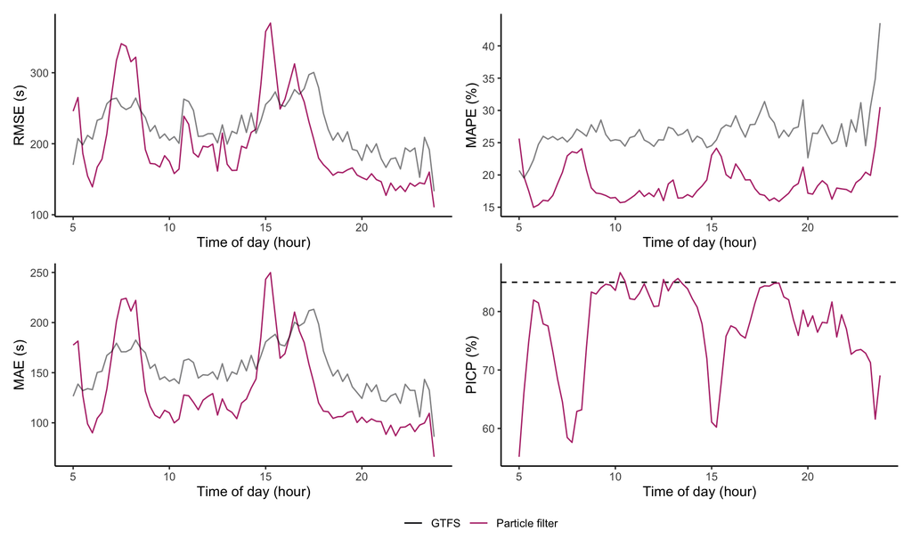

## Particle filter to predict arrival times

- Generally better than GTFS estimate
- Captures uncertainty during daytime off-peak
  - difficulty forecasting peak times (model not implemented)

# Conclusion

- GTFS network
  - match observations to physical roads
- Particle filter
  - flexible, multimodality, simple likelihood, estimation of road speeds
- Network state
  - updated in real-time from speed estimates, extensible (forecasts)
- Predictions
  - real-time network state, dwell times
- Journey planning
  - simplified CDF easy to share, calculate event probabilities
- `transitr` R package
  - future research, deployment

# Thank you

# References

Bérczi, K., Jüttner, A., Laumanns, M., & Szabó, J. (2017). Stochastic route planning in public transport. *Transportation Research Procedia*, *27*, 1080–1087. https://doi.org/10.1016/j.trpro.2017.12.096

Cathey, F. W., & Dailey, D. J. (2003). A prescription for transit arrival/departure prediction using automatic vehicle location data. *Transportation Research Part C: Emerging Technologies*, *11*(3-4), 241–264. https://doi.org/10.1016/s0968-090x(03)00023-8

Dailey, D., Maclean, S., Cathey, F., & Wall, Z. (2001). Transit vehicle arrival prediction: Algorithm and large-scale implementation. *Transportation Research Record: Journal of the Transportation Research Board*, *1771*, 46–51. https://doi.org/10.3141/1771-06

Hans, E., Chiabaut, N., Leclercq, L., & Bertini, R. L. (2015). Real-time bus route state forecasting using particle filter and mesoscopic modeling. *Transportation Research Part C: Emerging Technologies*, *61*, 121–140. https://doi.org/10.1016/j.trc.2015.10.017

Häme, L., & Hakula, H. (2013). Dynamic journeying under uncertainty. *European Journal of Operational Research*, *225*(3), 455–471. https://doi.org/10.1016/j.ejor.2012.10.027

Horn, M. E. T. (2004). Procedures for planning multi-leg journeys with fixed-route and demand-responsive passenger transport services. *Transportation Research Part C: Emerging Technologies*, *12*(1), 33–55. https://doi.org/10.1016/j.trc.2002.08.001

Jeong, R., & Rilett, L. (2005). Prediction model of bus arrival time for real-time applications. *Transportation Research Record: Journal of the Transportation Research Board*, *1927*, 195–204. https://doi.org/10.3141/1927-23

Julio, N., Giesen, R., & Lizana, P. (2016). Real-time prediction of bus travel speeds using traffic shockwaves and machine learning algorithms. *Research in Transportation Economics*, *59*, 250–257. https://doi.org/10.1016/j.retrec.2016.07.019

Plummer, M. (2003). *JAGS: A program for analysis of bayesian graphical models using gibbs sampling*.

Shalaby, A., & Farhan, A. (2004). Prediction model of bus arrival and departure times using AVL and APC data. *Journal of Public Transportation*, *7*(1), 41–61. https://doi.org/10.5038/2375-0901.7.1.3

Yu, B., Lam, W. H. K., & Tam, M. L. (2011). Bus arrival time prediction at bus stop with multiple routes. *Transportation Research Part C: Emerging Technologies*, *19*(6), 1157–1170. https://doi.org/10.1016/j.trc.2011.01.003

Yu, B., Yang, Z.-Z., & Yao, B. (2006). Bus arrival time prediction using support vector machines. *Journal of Intelligent Transportation Systems*, *10*(4), 151–158. https://doi.org/10.1080/15472450600981009

# Appendix

- GPS error distribution
- Information filter
- PF journey planning

# GPS error distribution

Observed shortest distance between $\boldsymbol{y}_k$ and the shape path $\mathcal{P}$.

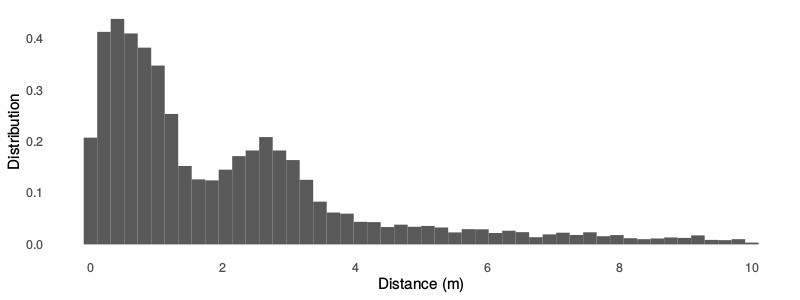

# Information filter

## Predict

- use standard Kalman filter prediction equations

$$\begin{split}
\hat\beta_{c|c-1} &= \hat\beta_{c-1|c-1} \\
P_{c|c-1} &= P_{c|c-1} + (\Delta_c q)^2
\end{split}$$

## Information fitler: update

- Information matrix, vector
  $$U = P^{-1}, \quad u = \hat\beta P^{-1}$$
- Obs. inf. matrix, vector; *include between-vehicle variance*
  $$I_v = (\phi^2 + e_v^2)^{-1},\quad i_v = b_v (\phi^2 + e_v^2)^{-1}$$
- Sum everything together
  $$\begin{split}
  U_{c|c} = U_{c|c-1} + \sum_v I_{v,c} \\
  u_{c|c} = u_{c|c-1} + \sum_v i_{v,c}
  \end{split}$$
- Back-transform

# Particle filter journey planning

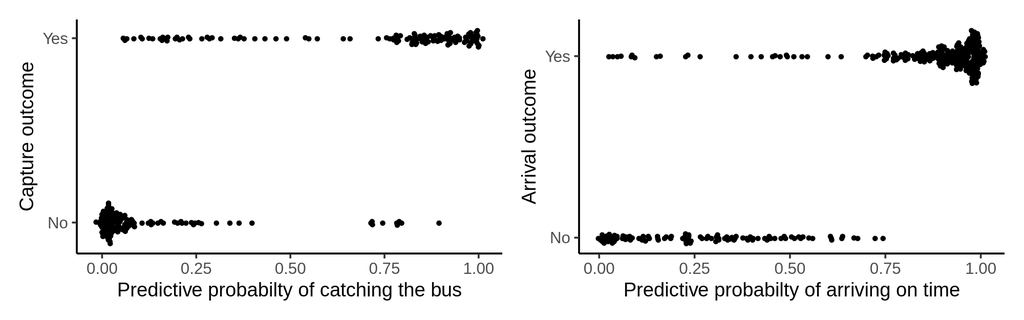

# Particle filter journey planning

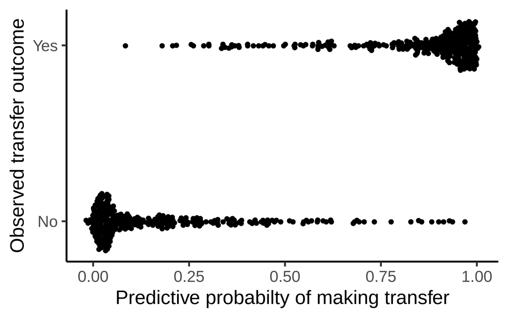